# EDS230: Assignment 4

Carlo Broderick, Erika Egg, Ruth Enriquez

```r
# Load packages
library(sensitivity)
library(tidyverse)
library(lhs)
library(purrr)
```

**Assignment Tasks**  
For a given forest, you will perform a sensitivity analysis of model predictions of conductance. Consider the sensitivity of your estimate to uncertainty in the following parameters and inputs

• height  
• kd  
• k0  
• v

Windspeeds v are normally distributed with a mean of 250 cm/s with a standard deviation of 30 cm/s  
For vegetation height assume that height is somewhere between 9.5 and 10.5 m (but any value in that range is equally likely)  
For the kd and k0 parameters you can assume that they are normally distributed with standard deviation of 1% of their default values

1. Use the Latin hypercube approach to generate parameter values for the 4 parameters

```r
# Set a random seed to make things 'random' reproducibly
set.seed(2)

# Specify parameters
pnames = c("v", "height","k_o", "k_d")

# Gather how many parameters
npar =  length(pnames)

# Choose how many samples
nsample = 50

# Create the random values array matrix using LHS for the parameters
parm_quant = randomLHS(nsample, npar)

# Assign the parameter names columns
colnames(parm_quant) = pnames

# Set up a data frame
parm = as.data.frame(matrix(nrow = nrow(parm_quant),
                            ncol = ncol(parm_quant)))

# Name data frame columns
colnames(parm) = pnames

# Create the samples for the different parameters

# To create the 1% standard deviation in next step
pvar = 100

# Normally distributed param samples
parm[,"v"] = qnorm(parm_quant[,"v"], mean=250, sd=30)
parm[,"k_d"] = qnorm(parm_quant[,"k_d"], mean=0.7, sd=0.7/pvar)
parm[,"k_o"] = qnorm(parm_quant[,"k_o"], mean=0.1, sd=0.1/pvar)

# Uniformly distributed param samples
parm[,"height"] = qunif(parm_quant[,"height"], min = 9.5, max = 10.5)
```

2. Run the atmospheric conductance model for these parameters

```r
# Run the hypercube through the model
Ca_outputs = pmap(parm, Catm)

# Turn results into an array for easy display/analysis
Cas = unlist(Ca_outputs)

# Put the outputs in the same df as the parameters
param_outputs <- parm %>%
  mutate(output = Cas)
```

3. Plot conductance estimates in a way that accounts for parameter uncertainty

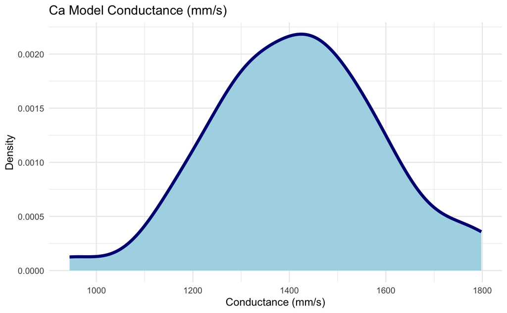

```r
# Plot predicted Ca for each parameter combo
ggplot(param_outputs, aes(x = output)) +
  geom_density(color = "navy", size = 1.5, fill = "lightblue") +
  theme_minimal() +
  labs(x = "Conductance (mm/s)", y = "Density", title = "Ca Model Conductance (mm/s)")
```

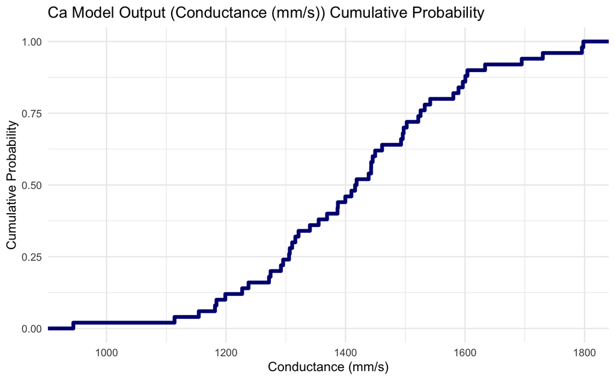

```r
# Plot cumulative distribution
ggplot(param_outputs, aes(x = output)) +
  stat_ecdf(color = "navy", size = 1.5) +
  theme_minimal() +
  labs(x = "Conductance (mm/s)", y = "Cumulative Probability", title = "Ca Model Output (Conductance (mm/s)) Cumulative Probability")
```

4. Plot conductance estimates against each of your parameters

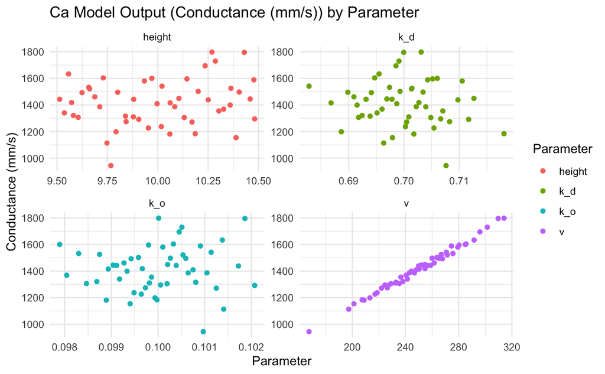

```r
# Make a df for the outputs pivoted longer for graphs
df_long <- param_outputs %>%
  pivot_longer(cols = v:k_d, names_to = "parm", values_to = "value")

# Create plots for parameters effect on output
ggplot(df_long, aes(x = value, y = output, col = parm)) +
  geom_point(size = 1.5) +
  facet_wrap(~ parm, ncol = 2, scales = "free") +
  theme_minimal() +
  labs(x = "Parameter", y = "Conductance (mm/s)", color = "Parameter", title = "Ca Model Output (Conductance (mm/s)) by Parameter")
```

5. Estimate the Partial Rank Correlation Coefficients

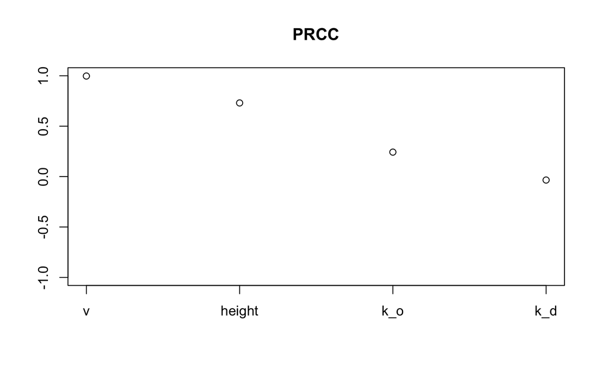

```r
# Calculate partial correlations
partial_correlation = pcc(parm, param_outputs$output, rank = TRUE)

# Plot them
plot(partial_correlation)
```

6. Discuss what your results tell you about how aerodynamic conductance? What does it suggest about what you should focus on if you want to reduce uncertainty in aerodynamic conductance estimates? Does this tell you anything about the sensitivity of plant water use to climate change?

**Answer:**

**Overview**

We suggest to reduce uncertainty that we look at wind speed (v) especially and also potentially height, as our results indicate that they are the two most important values to aerodynamic conductance and are most sensitive to change. This can be seen in the partial correlation graph which shows them as the highest values and clearly for wind speed in the positive correlation seen in the output by parameter plot. To summarize, since wind speed and height seem to be most sensitive to change, uncertainty in these parameters may be more likely to create an underestimate or overestimate of aerodynamic conductance, so focusing on these and ensuring accurate measurements for these are key. In general, if conductance is higher, then evapotranspiration increases which means more water use: if climate change causes windier conditions, for example, there could be greater plant water use (instability of wind conditions could impact water use).

**Further Discussion**

Looking at the results of our “Ca Model Output (Conductance (mm/s)) by Parameter” graph outputs we can see the different relationships conductance has on our parameters: height, k_d, k_o, and v. There does not seem to be a clear or strong relationship between conductance against height, k_d, & k_o. However, our graph suggests that there is a positive correlation between conductance and v. This suggests that the parameter v, being studied is an important factor in determining conductance. In conclusion, the results of the graphs suggest that it is important to consider multiple factors when estimating aerodynamic conductance.

To reduce uncertainty in aerodynamic conductance estimates, it may be necessary to consider multiple factors that influence conductance, such as vegetation structure, atmospheric conditions, and environmental factors. It may also be necessary to use more detailed models that account for the complexity of the relationship between these factors and conductance. Additionally, it may be important to collect more data to better understand the factors that influence conductance.

The sensitivity of plant water use to climate change depends on many factors, including changes in temperature, rainfall, and atmospheric conditions. Looking at our graphs it may suggests that the factors that influence plant water use, they may not provide a complete picture of how plants will respond to changes in climate. It is important to consider other factors that may influence plant water use, such as changes in plant species, soil moisture, and nutrient availability, when assessing the sensitivity of plant water use to climate change.